# EDA in an Issue Tracking Data Set

*by Dannyel Cardoso da Fonseca*

This project aims to explore a data set containing 22,125 observations of issues tracking and their history logs. The data set represents 5 years of project management which aimed maintenance and customization of many integrated systems ([SIG](https://docs.info.ufrn.br)) for the academic, administrative and human resources management at the Universidade Federal de Goiás ([UFG](https://www.ufg.br)).

A proprietary issue tracking system ([SIGProject](https://sigproject.esig.com.br)) was used to manage activities of teams.

[figure not shown]

I used data wrangling techniques to export data from that and clean them. The final data set, used in this project, and its documentation can be accessed, respectively, in these links:

- Issues Data Set
- Issues Data Set Documentation

The exported data set, the wrangling process scripts and an example of one issue tracking can be find in data_wrangling folder.

# Data Set Summaries

In this section I perform some preliminary exploration on the data set, analyzing its structure and the distributions of some variables.

### Data Set Structure

The issues data set contains 22,125 rows and 24 variables. Of these 24 variables 16 are about issue data and 8 about issue’s logs.

```
## 'data.frame':    22125 obs. of  24 variables:
##  $ issue_id             : int  487247 487247 ...
##  $ issue_number         : int  88374 88374 ...
##  $ issue_title          : chr  "Tarefa 88374 - Alteração de Finan"| __truncated__ ...
##  $ issue_type           : Factor w/ 4 levels "CUSTOMIZATION",..: 1 1 ...
##  $ issue_creation_date  : POSIXct, format: "2016-12-15 15:07:32" ...
##  $ issue_system         : Factor w/ 10 levels "INDEFINIDO","SERVICOS INTEGRADOS",..: 4 4 ...
##  $ issue_start_date     : Date, format: "2016-12-20" ...
##  $ issue_subsystem      : Factor w/ 77 levels "ADMINISTRAÇÃO",..: 34 34 ...
##  $ issue_deadline_date  : Date, format: "2017-01-03" ...
##  $ issue_created_by     : chr  "HELENA CLAUDIA DOS SANTOS TEIXEIRA" ...
##  $ issue_stakeholder    : Factor w/ 2 levels "COMPANY","CUSTOMER": 1 1 ...
##  $ issue_status         : Factor w/ 10 levels "CANCELED","CUSTOMER CLOSING PENDING",..: 3 3 ...
##  $ issue_time_spent     :Formal class 'Period' [package "lubridate"] with 6 slots
##  $ issue_priority_number: int  999 999 ...
##  $ issue_progress       : int  100 100 ...
##  $ issue_priority_scale : Factor w/ 6 levels "SUSPENDED","LOW",..: 4 4 ...
##  $ log_build_info       : chr  NA ...
##  $ log_creation_date    : POSIXct, format: "2017-04-10 17:07:00" ...
##  $ log_action           : Factor w/ 14 levels "CHANGE OF RESPONSIBILITY",..: 5 12 ...
##  $ log_status           : Factor w/ 34 levels "AUTHORIZED DEVELOPMENT",..: 7 4 ...
##  $ log_progress         : int  100 100 ...
##  $ log_time_spent       :Formal class 'Period' [package "lubridate"] with 6 slots
##  $ log_created_by       : chr  "ROSANGELA DIVINA DE SOUSA SANTANA" ...
##  $ log_svn_revision     : int  NA NA ...
```

The number of distinct issues rows and issue’s logs rows are 4,503 and 21,978 respectively.

```
##   number_issues number_logs
## 1          4503       21978
```

We can note that the number of issues represents 20% of the data set and the number of logs represents 99% of it. The 1% of logs remaining (147 rows) represents issues that do not have history logs. The distribution of number of logs per issue and their summaries are presented in the histogram below.

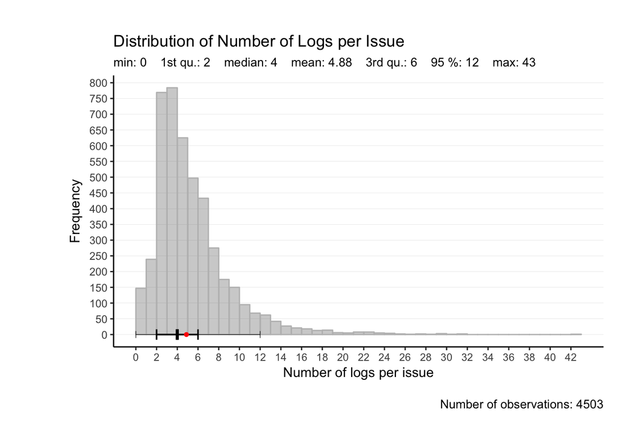

Analysing the plot above, we can note that 75% of issues have up to 6 history logs (before 3rd quartile) and 50% of issues have between 2 and 6 logs (between 1st and 3rd quartile). Besides the skewed shape of plot, the median and mean are very close. This means that the amount of ouliers, after 12 logs per issue, is low, approximately 5% of issues.

### Issue Creation Date

This data set comprises issues created in the period between 05/21/2013 and 01/26/2018.

```
##   first_issue_creation_date last_issue_creation_date
## 1       05/21/2013 19:10:24      01/26/2018 16:16:06
```

The distribution of number of issues created by month and the cumulative summaries are presented in the barplot below.

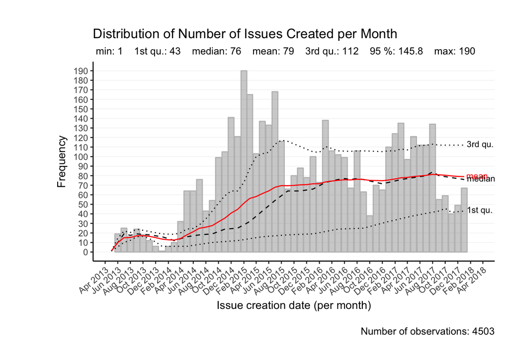

We also note that except the significant growth period (April of 2014 until February of 2015) the months from September to December of each year had a decline in activities. The reason is the low administrative and academic activities at the university in this period. Thus, the demand for the systems decreases.

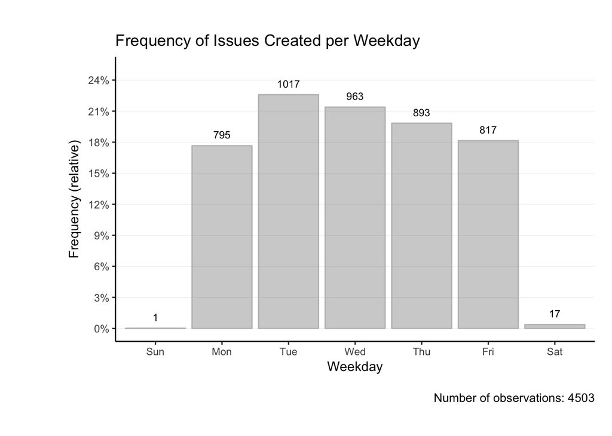

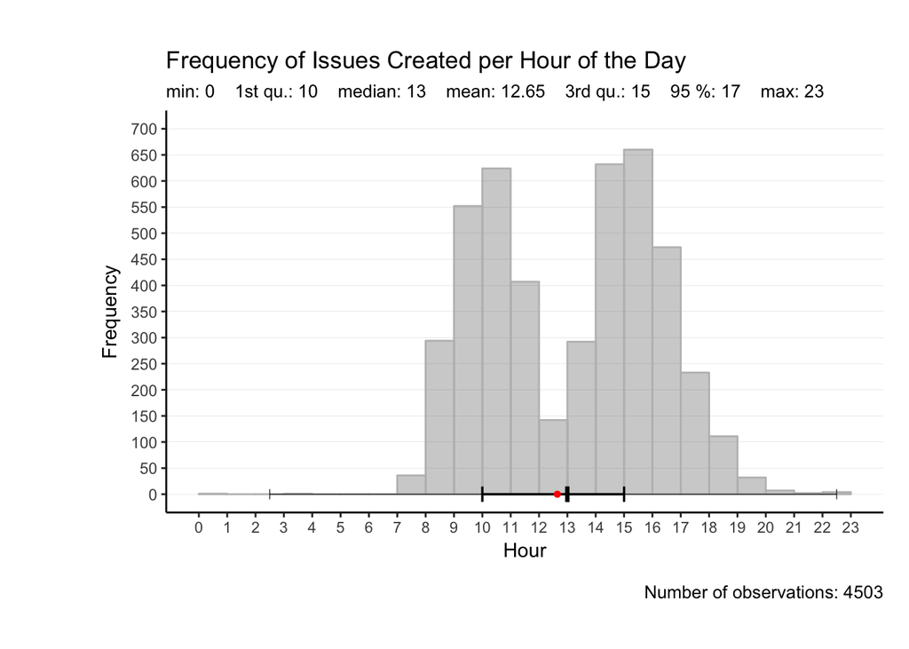

### Issue Start Date

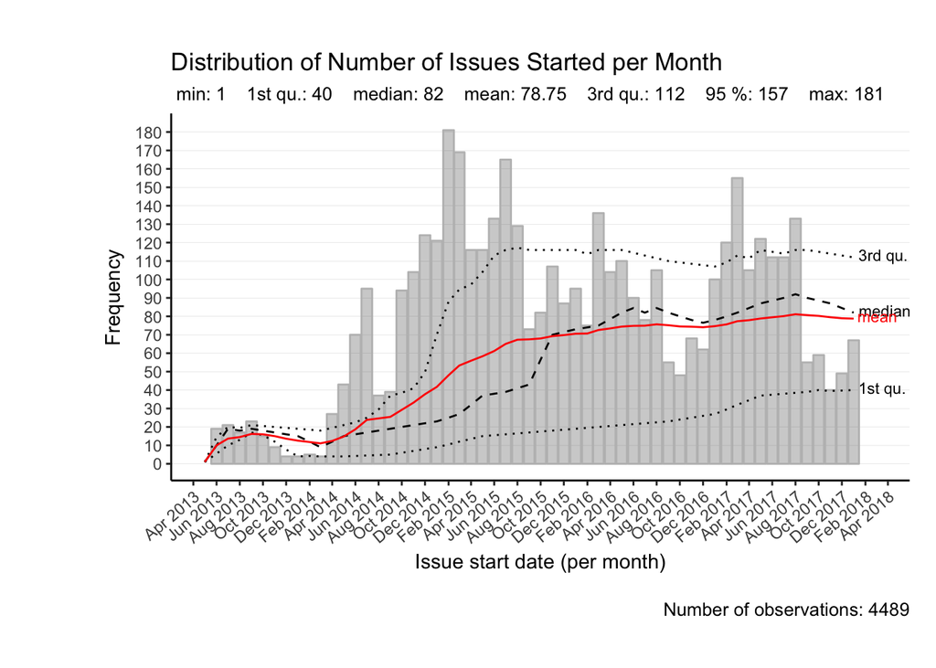

### Issue Deadline Date

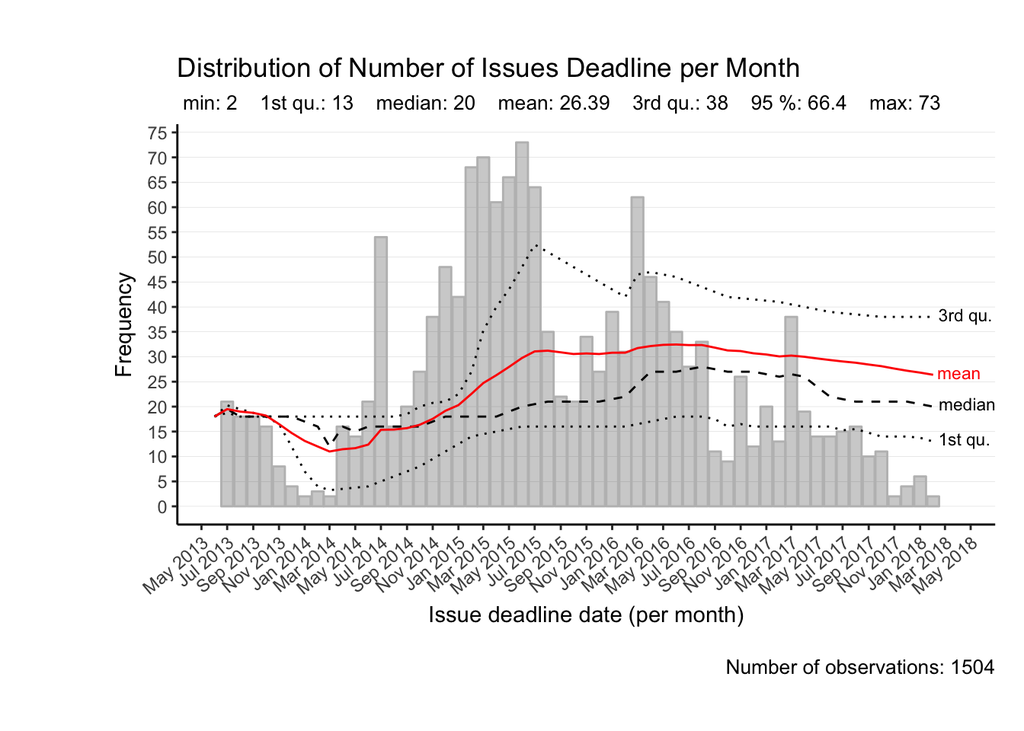

### Issue Time Spent

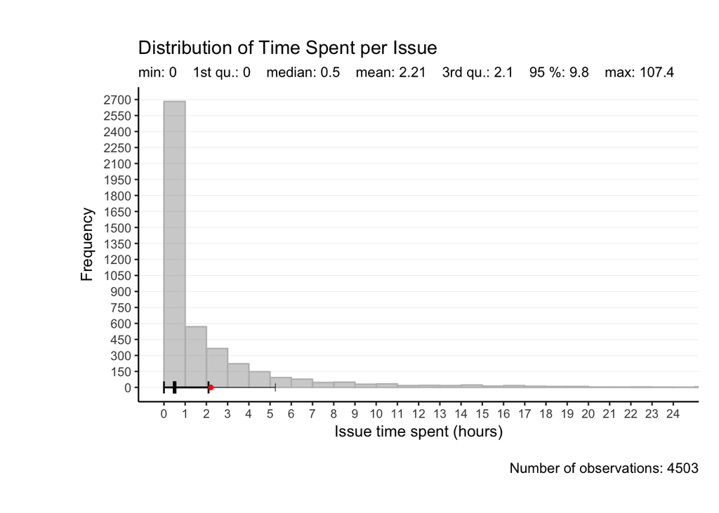

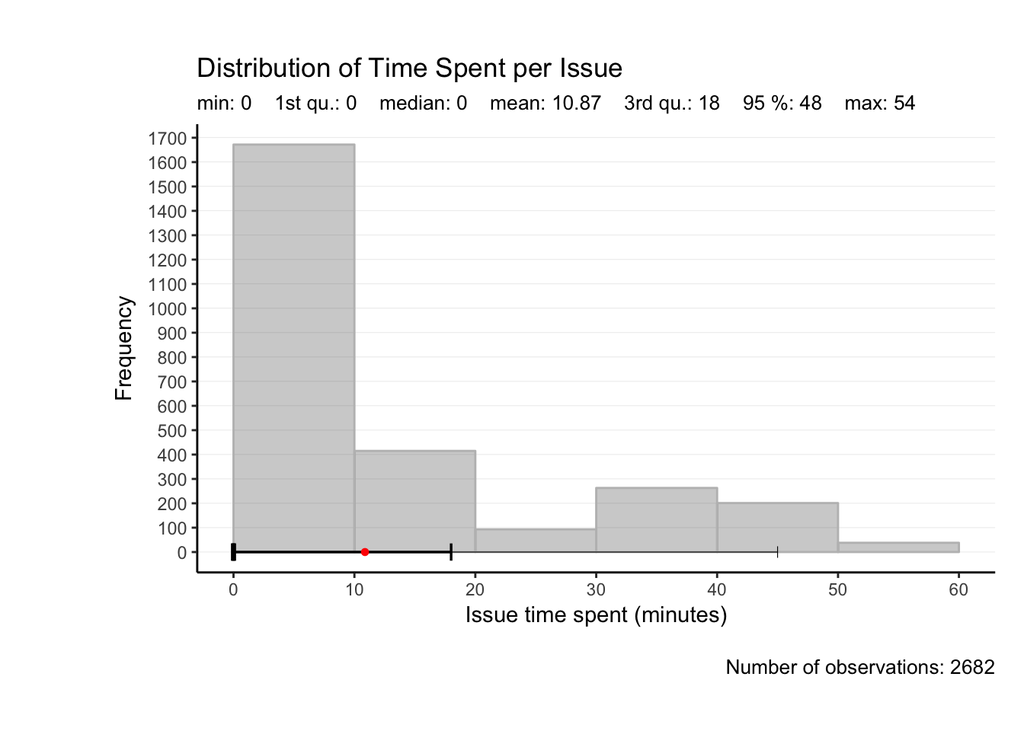

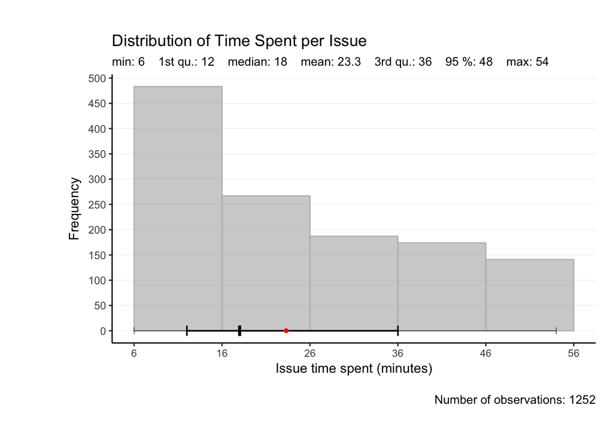

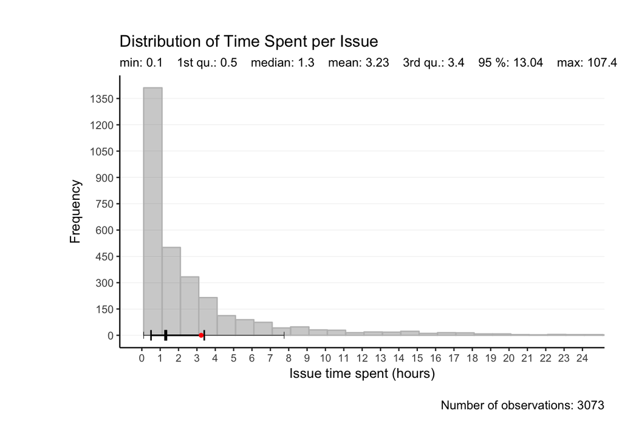

### Issue Type

In the issue tracking system, 4 types of issues were used to classify the purpose of a issue. They are:

```
## [1] "CUSTOMIZATION"  "DATA MIGRATION" "MAINTENANCE"    "OTHERS"
```

The frequency of issues created by each issue type is shown in the graph below.

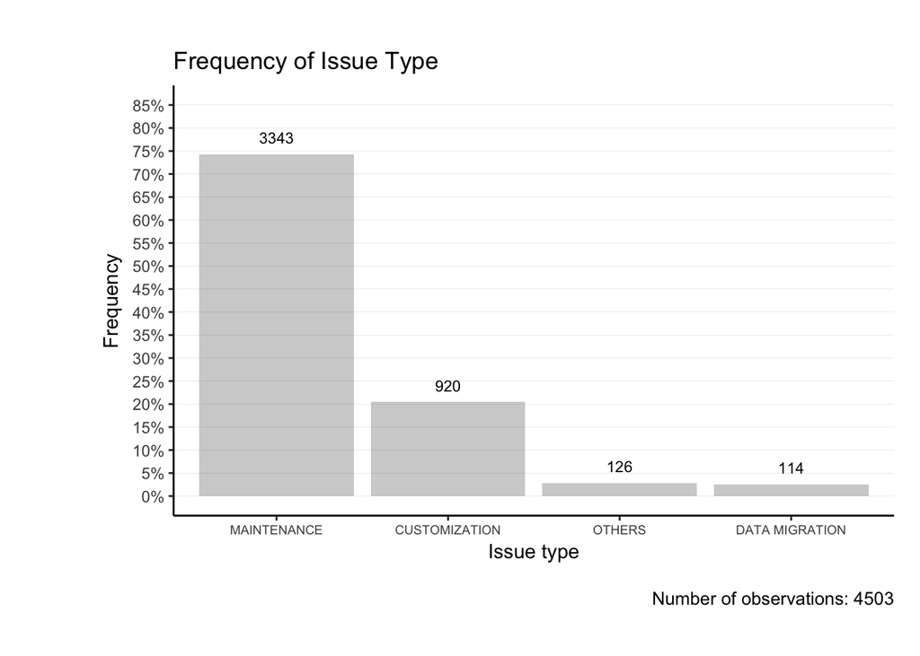

The demand for adaptation and evolution of the systems was not insignificant. Although the amount of CUSTOMIZATION and DATA MIGRATION issues are less than MAINTENANCE, they may have indirectly influenced in the creation of large volume of MAINTENANCE issues. Maybe, CUSTOMIZATION issues had provocated related creation of MAINTENANCE issues. The same is true for DATA MIGRATION. An analysis of issues creation timeline by system/subsystem may answer that assumption.

### Issue System

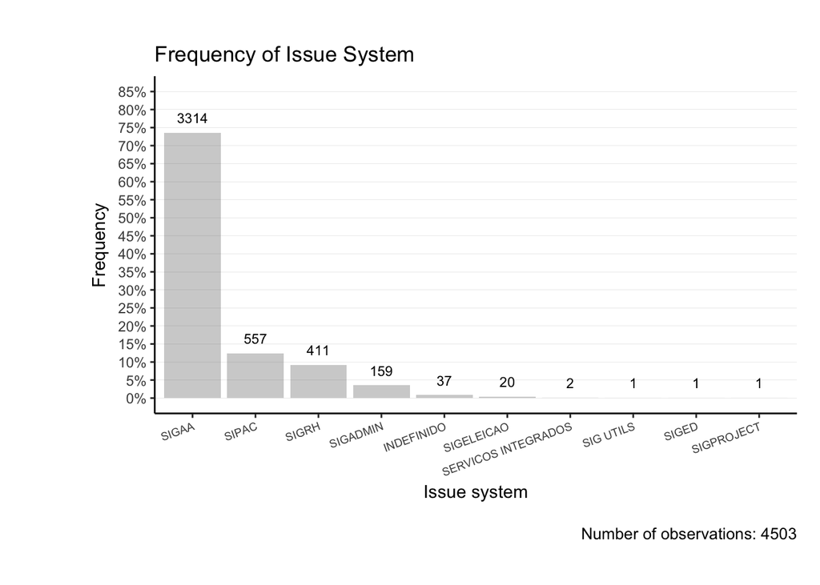

### Issue Subsystem

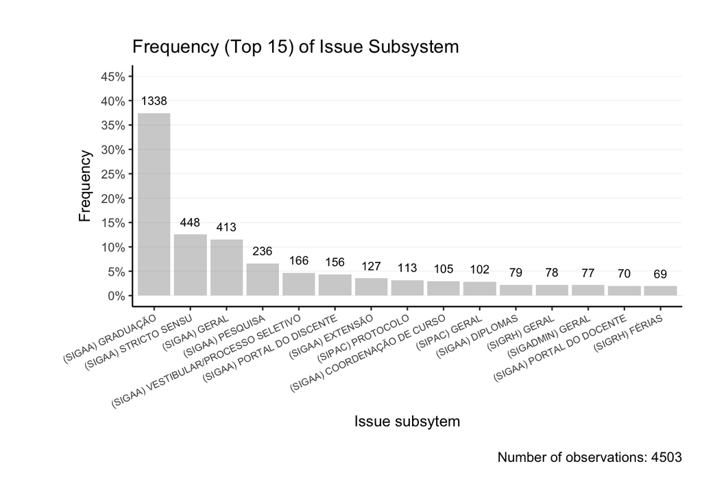

### Issue Stakeholder

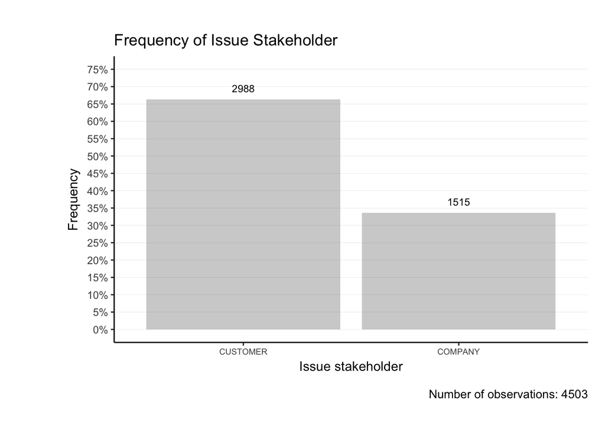

### Issue Created By

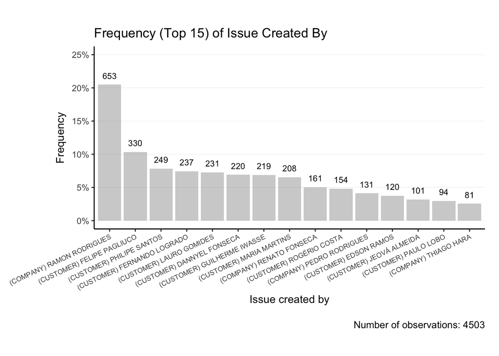

### Issue Status

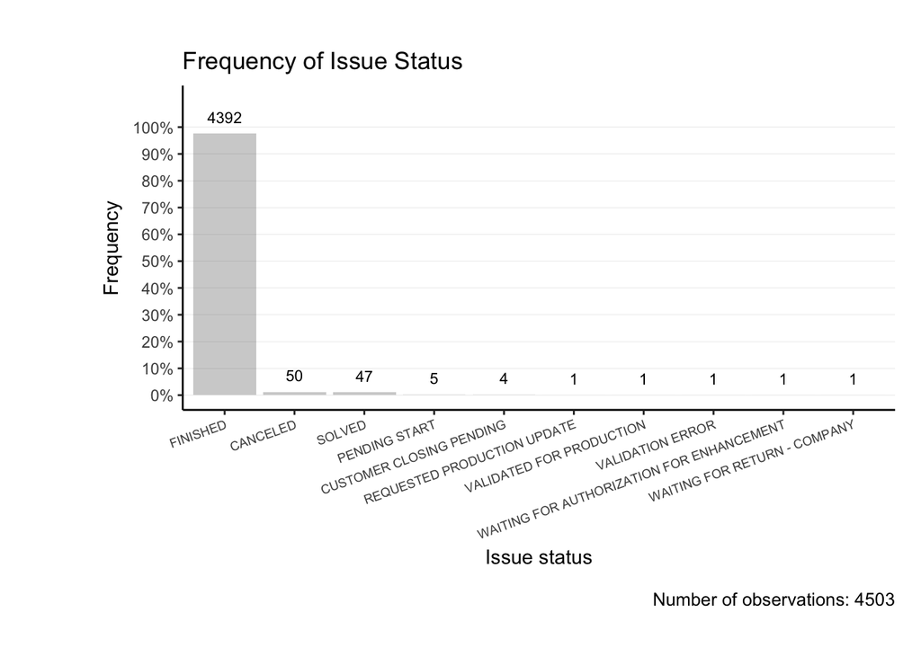

### Issue Priority Number

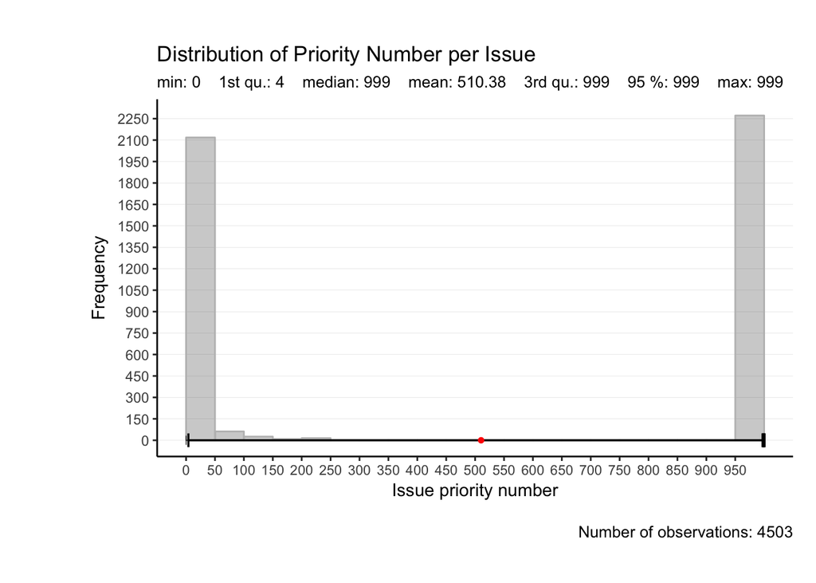

```
##   issue_priority_number score
## 1                   999  2272
## 2                     0   427
## 3                     1   243
## 4                     2   192
## 5                     3   148
## 6                     4   142
```

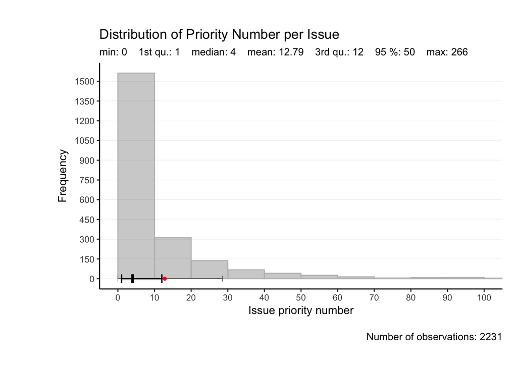

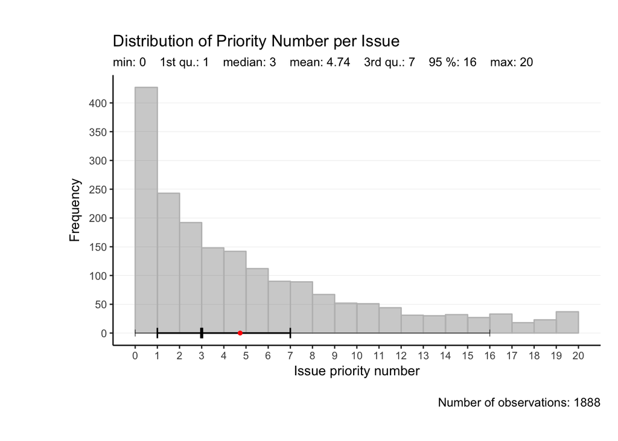

### Issue Priority Scale

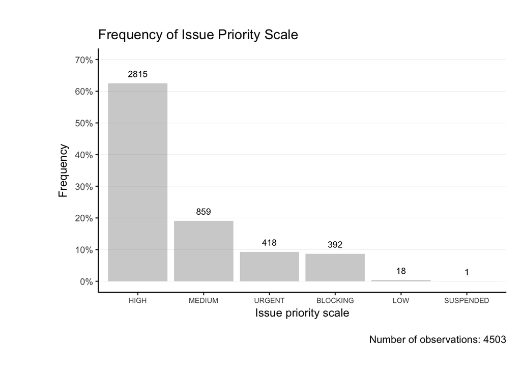

### Issue Progress

[figure not shown]

```
##   issue_progress score
## 1            100  4492
## 2              0     8
## 3             50     1
## 4             60     1
## 5             90     1
```

### Log Build Info

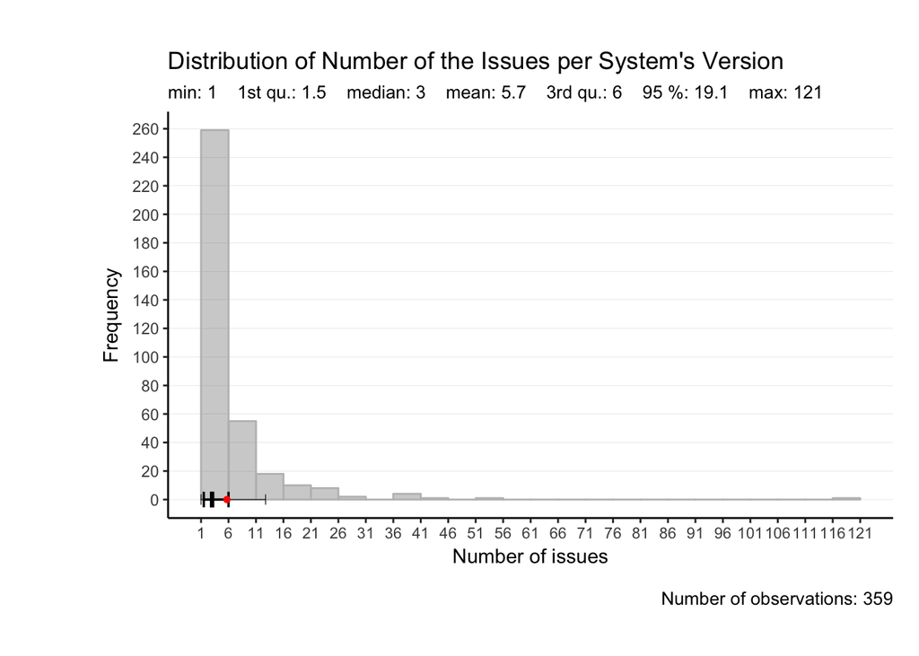

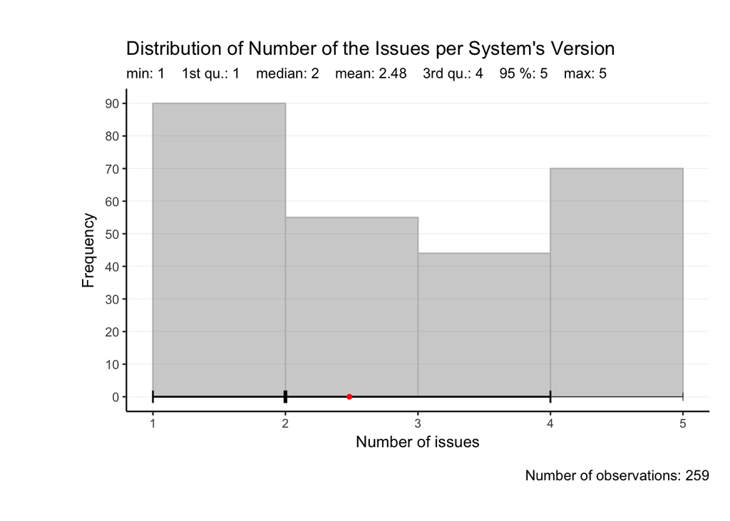

### Reflections on Data Set Summaries

What is the commom flow of the log states? (Data Set Structure)

What makes the demand low in 2013? What makes the demand grow rapidly in 2014?